# Day 20 Activity: Hierarchical Clustering of Colleges - SOLUTIONS

Your Name

ECON 122

## Introduction

In this activity, you’ll use hierarchical clustering to group colleges based on their characteristics. Unlike K-means clustering which requires you to specify the number of clusters beforehand, hierarchical clustering produces a dendrogram (tree) that shows the relationships between all cases, allowing you to choose the number of clusters after exploring the data structure.

**Learning Goals:**

- Apply hierarchical clustering to real data
- Interpret and visualize dendrograms
- Understand different linkage methods
- Cut dendrograms to create cluster assignments
- Compare hierarchical clustering to K-means

**Time:** Approximately 40 minutes

## Setup

Load the necessary packages:

```r
library(dplyr)
library(ggplot2)
library(readr)
library(tidyr)
```

**Note:** This activity uses the `dendextend` package for coloring dendrograms. If you don’t have it installed, you can install it with:

```r
install.packages("dendextend")
```

## Part 1: Load and Explore the Data (5 minutes)

We’ll use college data from California and Massachusetts. Limiting to these two states will make the dendrogram readable while still providing interesting diversity in school types.

```r
# Load the college data from CSV
colleges <- read_csv("https://raw.githubusercontent.com/mgelman/data/master/Colleges.csv")

# Create derived variables and select variables of interest
college_data <- colleges %>%
  mutate(
    avg_sat = (SATM + SATV) / 2,           # Average SAT score
    adm_rate = AppsAccept / AppsReceive,   # Admission rate
    cost = Tuition + RoomBoard + Books      # Total cost
  ) %>%
  # Select our variables of interest
  select(College, State,
         avg_sat,        # Average SAT score
         adm_rate,       # Admission rate
         HStop10,        # % of students from top 10% of HS class
         cost,           # Total cost
         Ratio,          # Student/faculty ratio
         Donate,         # % of alumni who donate
         AvgSalary,      # Average alumni salary
         FullTime        # Number of full-time students
  ) %>%
  # Filter for only CA and MA colleges
  filter(State %in% c("CA", "MA")) %>%
  # Remove rows with missing data
  filter(complete.cases(.))

# How many colleges remain after filtering?
nrow(college_data)
```

```
## [1] 40
```

**Q1: Just like in Day 19, filter the data to include only Claremont Colleges (Pomona College, Claremont McKenna College, Harvey Mudd College, Scripps College, and Pitzer College). Display their characteristics. Based on these characteristics, what other schools do you think they would cluster with?**

```r
# Filter for Claremont Colleges
claremont_colleges <- c("Pomona College", "Claremont McKenna College",
                        "Harvey Mudd College", "Scripps College", "Pitzer College")

claremont_data <- college_data %>%
  filter(College %in% claremont_colleges)

claremont_data
```

```
## # A tibble: 5 × 10
##   College   State avg_sat adm_rate HStop10  cost Ratio Donate AvgSalary FullTime
##   <chr>     <chr>   <dbl>    <dbl>   <dbl> <dbl> <dbl>  <dbl>     <dbl>    <dbl>
## 1 Claremon… CA        635    0.412      71 23510   9.6     52       601      887
## 2 Harvey M… CA        685    0.415      95 24620   8.2     46       638      654
## 3 Pitzer C… CA        575    0.556      37 24238  10.4     11       547      750
## 4 Pomona C… CA        670    0.372      80 25740   8.9     47       566     1500
## 5 Scripps … CA        575    0.739      60 25188   8.2     41       511      569
```

```r
# Summary statistics for Claremont Colleges
summary(claremont_data %>% select(-College, -State))
```

```
##     avg_sat       adm_rate         HStop10          cost           Ratio
##  Min.   :575   Min.   :0.3721   Min.   :37.0   Min.   :23510   Min.   : 8.20
##  1st Qu.:575   1st Qu.:0.4124   1st Qu.:60.0   1st Qu.:24238   1st Qu.: 8.20
##  Median :635   Median :0.4154   Median :71.0   Median :24620   Median : 8.90
##  Mean   :628   Mean   :0.4990   Mean   :68.6   Mean   :24659   Mean   : 9.06
##  3rd Qu.:670   3rd Qu.:0.5560   3rd Qu.:80.0   3rd Qu.:25188   3rd Qu.: 9.60
##  Max.   :685   Max.   :0.7392   Max.   :95.0   Max.   :25740   Max.   :10.40
##      Donate       AvgSalary        FullTime
##  Min.   :11.0   Min.   :511.0   Min.   : 569
##  1st Qu.:41.0   1st Qu.:547.0   1st Qu.: 654
##  Median :46.0   Median :566.0   Median : 750
##  Mean   :39.4   Mean   :572.6   Mean   : 872
##  3rd Qu.:47.0   3rd Qu.:601.0   3rd Qu.: 887
##  Max.   :52.0   Max.   :638.0   Max.   :1500
```

**Note:** The exact list of colleges in your dataset will depend on which CA and MA schools had complete data in the original dataset. You’ll discover the actual schools when you run the code!

**Your answer:**

Within our dataset of California and Massachusetts colleges, I expect them to cluster with other highly selective liberal arts colleges and elite universities.

**Likely types of schools in the same cluster:**

- **Elite research universities** (both public flagships and private institutions with very high selectivity)
- **Top-tier liberal arts colleges** (small, highly selective, with similar academic profiles)
- **Prestigious private universities** with strong academic reputations

These schools will share similar profiles of high selectivity, high costs, small student-faculty ratios, and strong academic reputations. The exact schools will be visible in the dendrogram and in Q9 when we examine the cluster membership.

## Part 2: Creating Your First Dendrogram (10 minutes)

For hierarchical clustering, we need the numeric variables only (not school names or state):

```r
# Create a dataset with only the clustering variables
cluster_vars <- college_data %>%
  select(avg_sat, adm_rate, HStop10, cost, Ratio, Donate, AvgSalary, FullTime)
```

Before we cluster, remember that hierarchical clustering uses distance measures, so we should standardize:

```r
# Standardize the clustering variables
cluster_vars_scaled <- scale(cluster_vars)
```

We’ll use the `dendextend` package to help us color the Claremont Colleges in our dendrograms:

```r
# Load dendextend package for dendrogram customization
library(dendextend)
```

**Why color the Claremont Colleges?** By highlighting the Claremont Colleges in red throughout our dendrograms, we can easily track where they appear in the tree structure and verify that they cluster with similar elite institutions. This visual aid helps us interpret the results more effectively.

**Important Note on dendrogram labels:** To display college names (instead of numbers) in our dendrograms, we must set the row names of our data matrix to the college names BEFORE running the clustering. This is done in Q2. Once set, all dendrograms will automatically show college names as labels, with the Claremont Colleges appearing in red.

**Better label spacing:** To make college names easier to read, we use:

1. **Large figure sizes** (`fig.height=8, fig.width=10` in the chunk options)
2. **Increased bottom margins** (`mar = c(15, 4, 4, 2)`) to give labels plenty of room
3. **Appropriate label size** (`cex = 0.6-0.7`) for readability

This combination ensures college names are clearly visible without overlapping!

**Q2: Use the `dist()` function to compute the distance matrix between all colleges using the scaled data. Then use `hclust()` to perform hierarchical clustering with complete linkage (the default). Store the result as `hc_complete`.**

```r
# IMPORTANT: Set row names to college names so dendrogram shows names not numbers
rownames(cluster_vars_scaled) <- college_data$College

# Step 1: Compute distance matrix
d <- dist(cluster_vars_scaled)

# Step 2: Run hierarchical clustering
hc_complete <- hclust(d)
```

**Q3: Plot the dendrogram using `plot()`. Based on the dendrogram, approximately how many natural clusters do you see? (Don’t worry about being exact - just give your initial impression)**

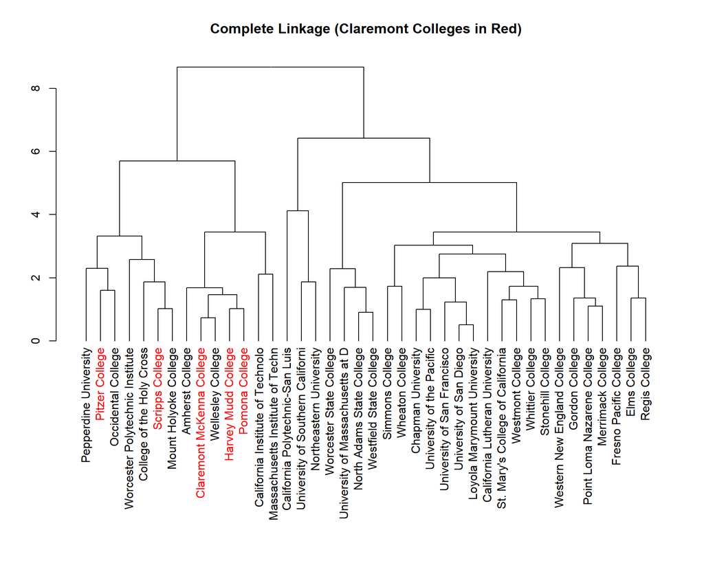

```r
# Load dendextend for easy label coloring
library(dendextend)

# Create color vector to highlight Claremont Colleges in red
label_colors <- ifelse(college_data$College %in% claremont_colleges, "red", "black")

# Create dendrogram object and color the labels
# Because we set rownames in Q2, the dendrogram labels are college names (not numbers!)
dend <- as.dendrogram(hc_complete)
labels_colors(dend) <- label_colors[order.dendrogram(dend)]

# Plot the colored dendrogram with all college names as labels
# Increase bottom margin and use larger figure size for better label spacing
par(mar = c(15, 4, 4, 2))  # Large bottom margin for labels
plot(dend, main = "Complete Linkage (Claremont Colleges in Red)",
     xlab = "", sub = "", cex = 0.7)
```

```r
par(mar = c(5, 4, 4, 2))  # Reset to default margins
# All colleges are labeled by name; Claremont Colleges appear in red
```

**Your answer:**

## Part 3: Cutting the Tree (10 minutes)

Now let’s cut the dendrogram to create specific cluster assignments.

**Q4: Use `cutree()` to cut the dendrogram into K=3 clusters. Add these cluster assignments to your `college_data` dataframe as a new column called `cluster_3`.**

```r
# Cut tree into 3 clusters
college_data <- college_data %>%
  mutate(cluster_3 = as.character(cutree(hc_complete, k = 3)))

# Check the distribution of clusters
table(college_data$cluster_3)
```

```
##
##  1  2  3
## 14 23  3
```

**Q5: Create a scatter plot of SAT scores vs. admission rates, colored by your cluster assignments from Q4. Also add labels for the Claremont Colleges.**

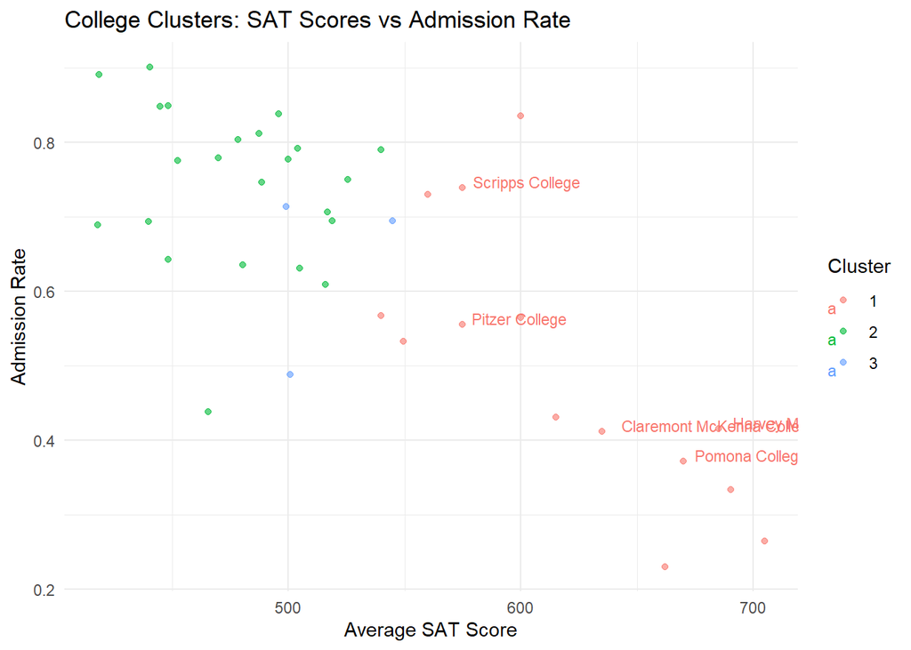

```r
# Create a label column for Claremont Colleges
college_data <- college_data %>%
  mutate(claremont_label = ifelse(College %in% claremont_colleges, College, ""))

# Create the scatter plot
ggplot(college_data, aes(x = avg_sat, y = adm_rate, color = cluster_3)) +
  geom_point(alpha = 0.6) +
  geom_text(aes(label = claremont_label), size = 3, hjust = -0.1, vjust = 0) +
  labs(title = "College Clusters: SAT Scores vs Admission Rate",
       x = "Average SAT Score",
       y = "Admission Rate",
       color = "Cluster") +
  theme_minimal()
```

**Your answer:**

**Q6: Now create another scatter plot of admission rate vs. cost, colored by the same cluster assignments. Does this help explain the cluster patterns?**

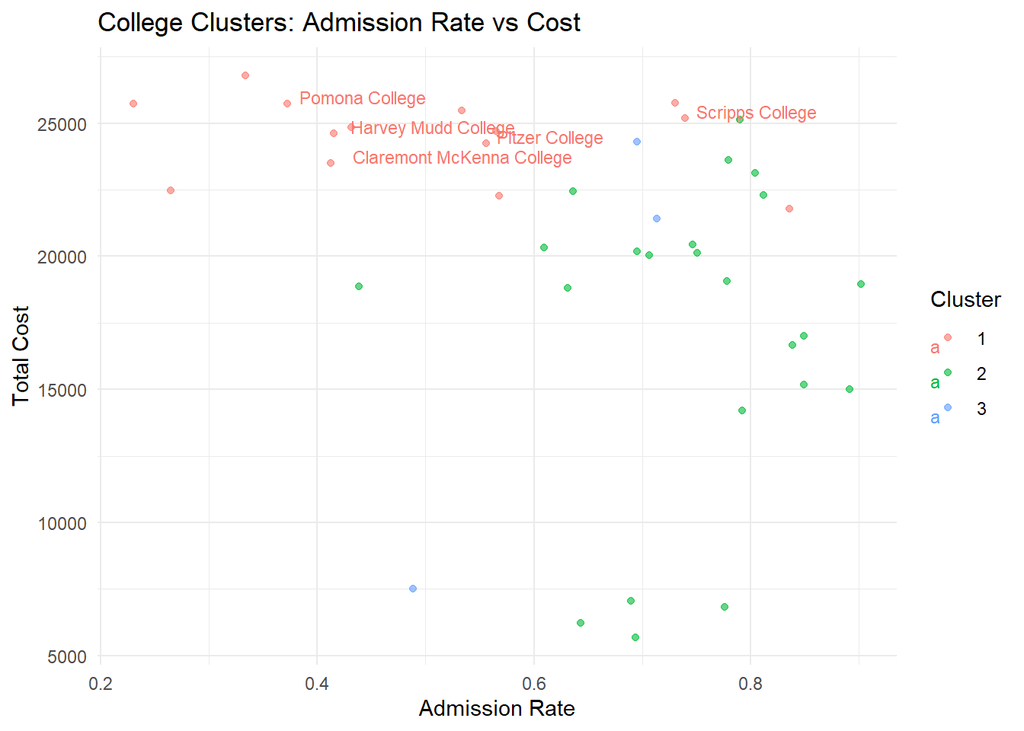

```r
# Scatter plot of admission rate vs cost
ggplot(college_data, aes(x = adm_rate, y = cost, color = cluster_3)) +
  geom_point(alpha = 0.6) +
  geom_text(aes(label = claremont_label), size = 3, hjust = -0.1, vjust = 0) +
  labs(title = "College Clusters: Admission Rate vs Cost",
       x = "Admission Rate",
       y = "Total Cost",
       color = "Cluster") +
  theme_minimal()
```

**Your answer:**

Yes, this plot helps explain the cluster patterns further. We can see that:

- The highly selective cluster (with low admission rates) tends to have higher costs
- There’s a negative relationship between admission rate and cost - more selective schools tend to be more expensive
- The clusters capture schools with similar combinations of selectivity and cost
- The Claremont Colleges, being highly selective and expensive, cluster with similar institutions

## Part 4: Exploring Different Numbers of Clusters (10 minutes)

Unlike K-means where we used the elbow plot, with hierarchical clustering we can visually inspect the dendrogram to decide where to cut.

**Q7: Try cutting the dendrogram at different heights. First, add horizontal lines to your dendrogram plot at heights of 2, 4, and 6. How many clusters would you get at each height?**

**Q7: Try cutting the dendrogram at different heights. First, add horizontal lines to your dendrogram plot at heights of 2, 4, and 6. How many clusters would you get at each height?**

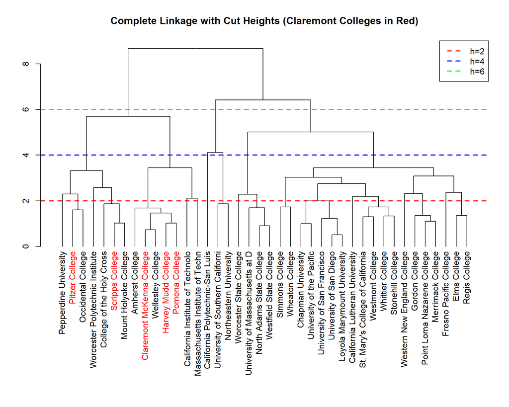

```r
# Plot dendrogram with horizontal lines at different heights
par(mar = c(15, 4, 4, 2))  # Large bottom margin for label spacing
plot(dend, main = "Complete Linkage with Cut Heights (Claremont Colleges in Red)",
     xlab = "", sub = "", cex = 0.7)

# Add horizontal lines at different heights
abline(h = 2, col = "red", lty = 2, lwd = 2)
abline(h = 4, col = "blue", lty = 2, lwd = 2)
abline(h = 6, col = "green", lty = 2, lwd = 2)

legend("topright", legend = c("h=2", "h=4", "h=6"),
       col = c("red", "blue", "green"), lty = 2, lwd = 2)
```

```r
par(mar = c(5, 4, 4, 2))  # Reset to default margins

# Count clusters at each height
cat("Clusters at height 2:", length(unique(cutree(hc_complete, h = 2))), "\n")
```

```
## Clusters at height 2: 19
```

```r
cat("Clusters at height 4:", length(unique(cutree(hc_complete, h = 4))), "\n")
```

```
## Clusters at height 4: 6
```

```r
cat("Clusters at height 6:", length(unique(cutree(hc_complete, h = 6))), "\n")
```

```
## Clusters at height 6: 3
```

**Your answer:**

**Q8: Based on your dendrogram, choose what you think is the optimal number of clusters and explain your reasoning. Then use `cutree()` to create cluster assignments with your chosen K value. Save this as `cluster_final` in your `college_data` dataframe.**

```r
# My chosen K value: 4
# This seems to capture meaningful groupings without being too granular or too broad

college_data <- college_data %>%
  mutate(cluster_final = as.character(cutree(hc_complete, k = 4)))

# Check the distribution
table(college_data$cluster_final)
```

```
##
##  1  2  3  4
##  7 23  3  7
```

**Your answer (explain your choice):**

**Q9: Find which cluster contains the Claremont Colleges, and show 10 other schools in that same cluster. Are these the types of schools you predicted in Q1?**

```r
# Find the cluster for Claremont Colleges
claremont_cluster <- college_data %>%
  filter(College %in% claremont_colleges) %>%
  select(College, cluster_final) %>%
  print()
```

```
## # A tibble: 5 × 2
##   College                   cluster_final
##   <chr>                     <chr>
## 1 Claremont McKenna College 1
## 2 Harvey Mudd College       1
## 3 Pitzer College            4
## 4 Pomona College            1
## 5 Scripps College           4
```

```r
# Get the cluster number (assuming they're all in the same cluster)
target_cluster <- claremont_cluster$cluster_final[1]

# Show other schools in the same cluster
# These are the ACTUAL schools in your dataset!
college_data %>%
  filter(cluster_final == target_cluster,
         !College %in% claremont_colleges) %>%
  select(College, State, avg_sat, adm_rate, cost) %>%
  head(10)
```

```
## # A tibble: 4 × 5
##   College                          State avg_sat adm_rate  cost
##   <chr>                            <chr>   <dbl>    <dbl> <dbl>
## 1 California Institute of Technolo CA       705     0.265 22481
## 2 Amherst College                  MA       662     0.231 25720
## 3 Massachusetts Institute of Techn MA       690.    0.334 26800
## 4 Wellesley College                MA       615     0.431 24840
```

**Tip:** You can also look at the dendrogram from Q3 or Q7 to visually see which schools (in red for Claremont Colleges, in black for others) are clustered together at the bottom of the tree!

**Your answer:**

**What to look for when examining your results:**

Looking at the schools listed above from your actual cluster output, you should see:

1. **High SAT scores**: Most schools in this cluster will have average SAT scores in the 650-750+ range
2. **Low admission rates**: Most schools will be highly selective, with admission rates typically under 30-40%
3. **High costs**: These will be primarily expensive private institutions
4. **Strong academic reputations**: You should recognize these as prestigious, well-known colleges and universities
5. **Geographic diversity**: The cluster includes elite schools from both California and Massachusetts

**Common types of schools you’ll find:**

- Elite research universities (private and possibly flagship publics)
- Top-tier liberal arts colleges
- Highly selective institutions known for strong academics

This confirms that hierarchical clustering successfully identified the “elite college” category, grouping together the most selective and prestigious institutions from both coasts. The clustering algorithm found schools that share similar quantitative characteristics (SAT scores, admission rates, costs, etc.) which correspond to schools with similar academic reputations.

## Part 5: Comparing Linkage Methods (10 minutes)

Hierarchical clustering can use different linkage methods to compute distances between clusters. Let’s compare complete linkage (what we’ve been using) with average linkage.

**Q10: Perform hierarchical clustering again using average linkage instead of complete linkage. Create the dendrogram and compare it visually to the complete linkage dendrogram.**

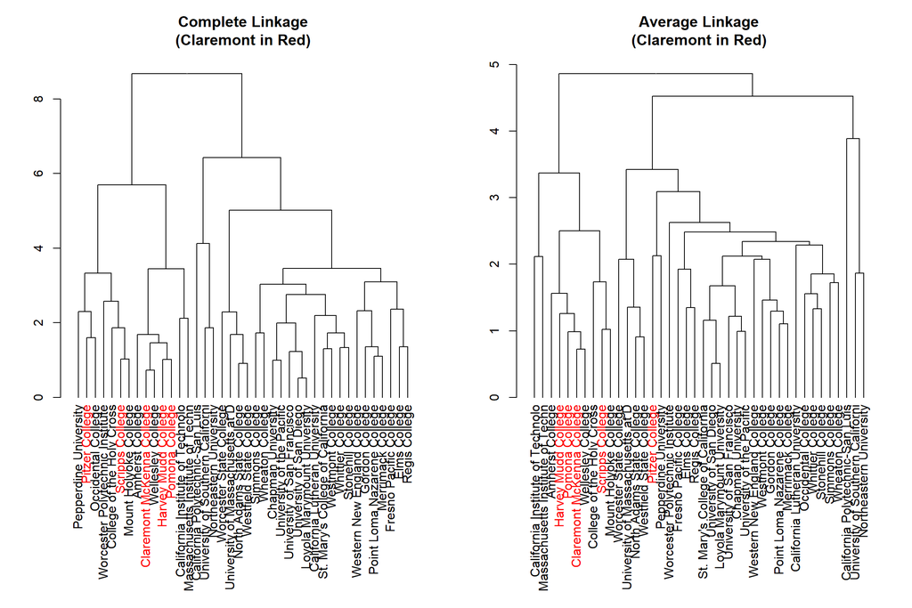

```r
# Perform hierarchical clustering with average linkage
# Uses the same distance matrix d (which has college names as labels)
hc_average <- hclust(d, method = "average")

# Create dendrogram objects with colored labels for Claremont Colleges
dend_complete <- as.dendrogram(hc_complete)
dend_average <- as.dendrogram(hc_average)

# Color the labels (red for Claremont Colleges)
labels_colors(dend_complete) <- label_colors[order.dendrogram(dend_complete)]
labels_colors(dend_average) <- label_colors[order.dendrogram(dend_average)]

# Plot both dendrograms side by side
par(mfrow = c(1, 2), mar = c(13, 4, 4, 2))  # 2 plots, large bottom margin
plot(dend_complete, main = "Complete Linkage\n(Claremont in Red)",
     xlab = "", sub = "", cex = 0.6)
plot(dend_average, main = "Average Linkage\n(Claremont in Red)",
     xlab = "", sub = "", cex = 0.6)
```

```r
par(mfrow = c(1, 1), mar = c(5, 4, 4, 2))  # Reset to defaults
```

**Your answer:**

The two dendrograms show some differences:

1. **Height scale**: The average linkage dendrogram has a smaller overall height compared to complete linkage, with fusions happening at lower heights
2. **Tree structure**: The branching patterns are somewhat different. Complete linkage tends to create more distinct, separated clusters, while average linkage produces a more “chained” structure
3. **Cluster balance**: Complete linkage tends to produce more balanced clusters, while average linkage may create some more elongated chains
4. **Overall pattern**: Despite these differences, the major groupings are relatively similar - elite schools still cluster together, less selective schools cluster together, etc.

**Q11: Cut the average linkage dendrogram into the same number of clusters you chose in Q8. Create a table comparing how many colleges are assigned to each cluster under complete vs. average linkage.**

```r
# Add cluster assignments from average linkage
college_data <- college_data %>%
  mutate(cluster_average = as.character(cutree(hc_average, k = 4)))

# Create a cross-tabulation
cluster_comparison <- table(Complete = college_data$cluster_final,
                            Average = college_data$cluster_average)
cluster_comparison
```

```
##         Average
## Complete  1  2  3  4
##        1  7  0  0  0
##        2  0 23  0  0
##        3  0  0  1  2
##        4  3  4  0  0
```

```r
# Calculate agreement
agreement <- sum(diag(cluster_comparison)) / sum(cluster_comparison)
cat("\nOverall agreement (same cluster under both methods):",
    round(agreement * 100, 1), "%\n")
```

```
##
## Overall agreement (same cluster under both methods): 77.5 %
```

```r
# Show which Claremont colleges are in which clusters
college_data %>%
  filter(College %in% claremont_colleges) %>%
  select(College, cluster_final, cluster_average)
```

```
## # A tibble: 5 × 3
##   College                   cluster_final cluster_average
##   <chr>                     <chr>         <chr>
## 1 Claremont McKenna College 1             1
## 2 Harvey Mudd College       1             1
## 3 Pitzer College            4             2
## 4 Pomona College            1             1
## 5 Scripps College           4             1
```

**Your answer:**

## Part 6: Reflection Questions

**Q12: What are the main advantages of hierarchical clustering compared to K-means clustering? What are the disadvantages?**

**Your answer:**

**Advantages:**

1. **No need to specify K beforehand**: You can explore the dendrogram and choose the number of clusters after seeing the data structure
2. **Provides rich visualization**: The dendrogram shows not just cluster membership but also the relationships and similarities between all observations
3. **Deterministic**: Given the same linkage method and distance measure, you always get the same result (no random initialization like K-means)
4. **Hierarchical structure**: You can see clusters at multiple levels of granularity simultaneously
5. **Works with any distance measure**: Not limited to Euclidean distance

**Disadvantages:**

1. **Computationally expensive**: O(n²) for distance matrix computation and O(n² log n) for clustering, making it impractical for very large datasets (K-means is much faster)
2. **Cannot revise**: Once two clusters are merged, they cannot be unmerged (K-means can reassign points in each iteration)
3. **Sensitive to outliers**: Particularly with complete and single linkage methods
4. **Choice of linkage**: Results can vary substantially depending on the linkage method chosen
5. **No objective function**: Unlike K-means which minimizes within-cluster variation, hierarchical clustering doesn’t optimize a clear objective

**Q13: Why is it still important to standardize variables before performing hierarchical clustering, even though it creates a tree structure?**

**Your answer:**

Standardization is crucial for hierarchical clustering because:

1. **Distance calculations**: Hierarchical clustering relies on distance measures (typically Euclidean distance) to determine similarity. If variables are on different scales, variables with larger ranges will dominate the distance calculations
2. **Example**: In our college data, `FullTime` (number of students) ranges from hundreds to thousands, while `adm_rate` (admission rate) ranges from 0 to 1. Without standardization, differences in enrollment would completely overwhelm differences in admission rates
3. **Equal weighting**: Standardization ensures that each variable contributes equally to the clustering decision, which is usually what we want when we include multiple variables
4. **Interpretability**: With standardized variables, the height of the dendrogram represents distance in terms of standard deviations, making it easier to interpret

Just like with K-means, failing to standardize can lead to clusters that are driven almost entirely by the variables with the largest scales, missing important patterns in other variables.

**Q14: In hierarchical clustering, you can cut the tree at different heights to get different numbers of clusters. How is this different from running K-means multiple times with different K values? Which approach do you find more intuitive?**

**Your answer:**

**Differences:**

1. **Single analysis vs. multiple runs**:
   - Hierarchical: Build the tree once, then cut it at different heights - all potential K values come from one analysis
   - K-means: Must run the algorithm separately for each K value you want to try
2. **Relationships between solutions**:
   - Hierarchical: Cutting at different heights creates nested clusters (smaller clusters are contained within larger clusters)
   - K-means: Each K gives an independent solution - clusters from K=3 are not necessarily related to clusters from K=4
3. **Visualization**:
   - Hierarchical: The dendrogram shows all possible cluster solutions simultaneously
   - K-means: Need separate plots (like elbow plots) to compare different K values
4. **Decision process**:
   - Hierarchical: Choose where to cut based on visual inspection of gaps in the dendrogram
   - K-means: Choose K based on elbow plot or other criteria like within-cluster sum of squares

**Which is more intuitive?**

I find hierarchical clustering more intuitive because:

- The dendrogram provides a complete picture of the data structure at all levels
- You can see the “story” of how clusters merge together
- It’s easier to identify natural groupings by looking for large jumps in height
- However, K-means is more intuitive in terms of the optimization goal (minimize within-cluster variation)

Both have their place depending on the analysis goals and data size.

**Q15: Looking at your final clusters, do you think the hierarchical clustering method captured meaningful groupings of colleges? If you were a prospective student using this analysis, how might it help you identify schools to consider?**

**Your answer:**

Yes, the hierarchical clustering captured very meaningful groupings of colleges within our California and Massachusetts dataset. The clusters clearly separate schools by:

1. **Selectivity level**: Elite/highly selective (top-tier universities and liberal arts colleges) vs. moderately selective vs. less selective
2. **Cost**: Expensive private schools vs. more affordable options
3. **Student body characteristics**: High-achieving student bodies (high SAT scores, top 10% HS students) vs. more diverse academic profiles
4. **Institutional type**: Small liberal arts colleges vs. larger research universities vs. regional universities

**As a prospective student, this analysis would be helpful because:**

1. **Find similar schools**: If I’m interested in one school (e.g., Pomona College), I can look at others in the same cluster to find schools with similar characteristics
2. **Geographic comparison**: Since we have both CA and MA schools, I can see which schools on the East Coast are similar to my California preferences (or vice versa). For example, if I like the Claremont Colleges in California, I can find similar small liberal arts colleges in Massachusetts
3. **Target appropriate schools**: The clusters help identify schools where my academic profile (SAT scores, etc.) would be competitive
4. **Explore alternatives**: I might discover schools I hadn’t considered that are similar to my top choices
5. **Financial planning**: Clusters help group schools by cost, helping with financial planning
6. **Balanced list**: I could select schools from different clusters to create a balanced application list (reach, target, and safety schools)

For example, if I’m interested in Pomona College in California but want to explore East Coast alternatives, looking at the other schools in its cluster would show me which Massachusetts liberal arts colleges have similar profiles. Similarly, a Massachusetts student interested in highly selective schools can discover that the Claremont Colleges are West Coast alternatives with similar characteristics.

## Bonus Challenge (Optional)

**Q16: Use the `dendextend` package to create a colored dendrogram where branches are colored by cluster membership. Then create a tanglegram comparing complete and average linkage results.**

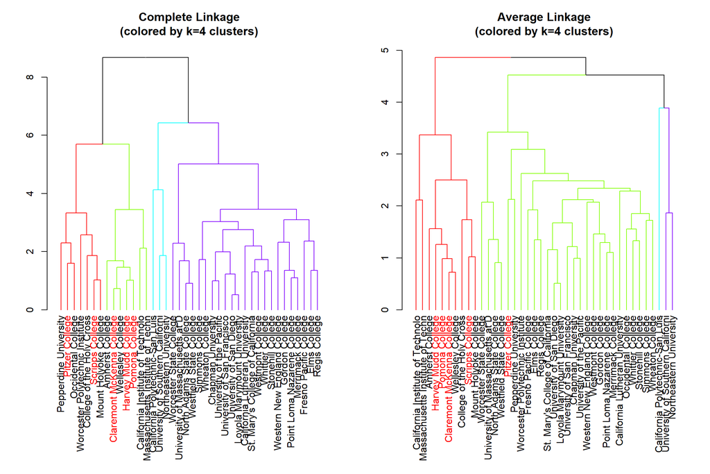

```r
# We've already loaded dendextend and created dendrograms with Claremont labels colored
# Now let's color branches by cluster membership (k=4)
dend_complete_clusters <- color_branches(dend_complete, k = 4)
dend_average_clusters <- color_branches(dend_average, k = 4)

# Plot colored dendrograms by cluster
par(mfrow = c(1, 2), mar = c(13, 4, 4, 2))  # Increase bottom margin for labels
plot(dend_complete_clusters, main = "Complete Linkage\n(colored by k=4 clusters)",
     xlab = "", sub = "", cex = 0.6)
plot(dend_average_clusters, main = "Average Linkage\n(colored by k=4 clusters)",
     xlab = "", sub = "", cex = 0.6)
```

```r
par(mfrow = c(1, 1), mar = c(5, 4, 4, 2))  # Reset to defaults
```

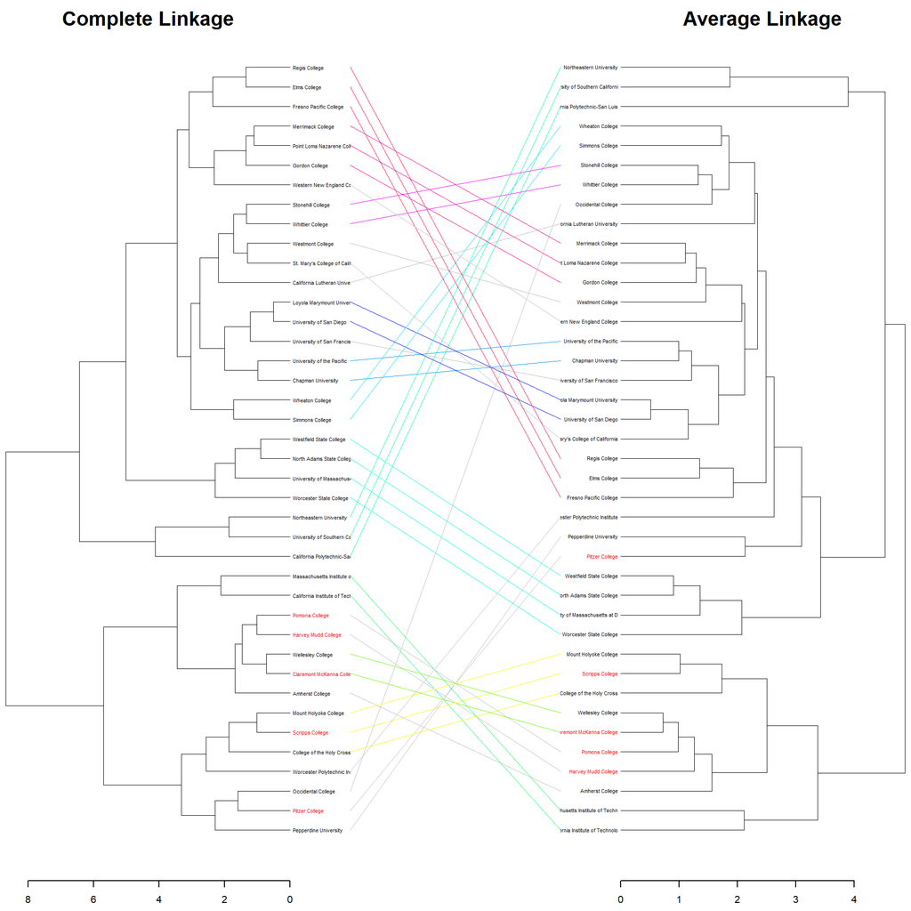

```r
# Create a tanglegram to compare the two methods
# We'll use the label-colored versions (with Claremont in red) for the tanglegram
dend_list <- dendlist("Complete Linkage" = dend_complete, "Average Linkage" = dend_average)

tanglegram(dend_list,
           highlight_distinct_edges = FALSE,
           common_subtrees_color_lines = TRUE,
           margin_inner = 5,  # Space between the two dendrograms
           lwd = 0.5,
           edge.lwd = 0.5,
           lab.cex = 0.5)
```